# Week 10 Lab - KEY

Prof. Amanda D. Perez, PhD

# Logistic Regression: Titanic Data

```r
library(tidyverse)
library(sjlabelled)
library(haven)
library(knitr)
library(broom)
library(dplyr)
library(viridis)
```

For this section you are going to run and interpret a logistic regression on real data on Titanic survival rates. Specifically, you will be looking at how Sex, Age, and Passenger Class impact survival odds.

```r
titanic <- read_csv("data/titanic.csv")

titanic <- titanic %>%
  select(c("Survived", "Sex", "Pclass", "Age"))


glimpse(titanic)
```

```
## Rows: 891
## Columns: 4
## $ Survived <dbl> 0, 1, 1, 1, 0, 0, 0, 0, 1, 1, 1, 1, 0, 0, 0, 1, 0, 1, 0, 1, 0…
## $ Sex      <chr> "male", "female", "female", "female", "male", "male", "male",…
## $ Pclass   <dbl> 3, 1, 3, 1, 3, 3, 1, 3, 3, 2, 3, 1, 3, 3, 3, 2, 3, 2, 3, 3, 2…
## $ Age      <dbl> 22, 38, 26, 35, 35, NA, 54, 2, 27, 14, 4, 58, 20, 39, 14, 55,…
```

We will convert *Survived* and *Pclass* to labeled factors to facilitate interpretation and the construction of graphs.

```r
titanic$Sex <-  as.factor(titanic$Sex)

titanic <- titanic %>%
  mutate(survived_factor = factor(Survived,
                                levels = 0:1,
                                labels = c("Drowned", "Survived")),
         class_factor   = factor(Pclass,
                                levels = 1:3,
                                labels = c("first",
                                           "second",
                                           "third")))
```

## Titanic Data Visualization

The first step in any statistical analysis should be to perform a visual inspection of the data in order to check for coding errors, outliers, or funky distributions.

The variable *Survived* is the dependent variable. We can check the distribution of responses using the count function:

```r
titanic %>%
  count(survived_factor) %>%
  mutate(prop = prop.table(n)) %>%
  kable(align = c("l","c","c"),
        col.names = c("Survived", "N", "Proportion"),
        digits = 3)
```

| Survived | N | Proportion |
| --- | --- | --- |
| Drowned | 549 | 0.616 |
| Survived | 342 | 0.384 |

Now we will review the distribution for the other categorical variables, *Sex* and *Class*

```r
titanic %>%
  count(Sex) %>%
  mutate(prop = prop.table(n))%>%
  kable(align = c("l","c","c"),
        col.names = c("Sex", "N", "Proportion"),
        digits = 3)
```

| Sex | N | Proportion |
| --- | --- | --- |
| female | 314 | 0.352 |
| male | 577 | 0.648 |

```r
titanic %>%
  count(class_factor) %>%
  mutate(prop = prop.table(n))%>%
  kable(align = c("l","c","c"),
        col.names = c("Class", "N", "Proportion"),
        digits = 3)
```

| Class | N | Proportion |
| --- | --- | --- |
| first | 216 | 0.242 |
| second | 184 | 0.207 |
| third | 491 | 0.551 |

We can also check out the distribution of age. We will create a table of summary statistics using the summarise function.

```r
titanic %>%
  summarise(Min    = min(Age, na.rm = T),
            Max    = max(Age, na.rm = T),
            Median = median(Age, na.rm = T),
            Mean   = mean(Age, na.rm = T),
            SD     = sd(Age, na.rm = T)) %>%
  mutate_all(~round(., 3)) %>%
  kable(align = rep("c", 4))
```

| Min | Max | Median | Mean | SD |
| --- | --- | --- | --- | --- |
| 0.42 | 80 | 28 | 29.699 | 14.526 |

## Exercise 1: Values

What is the minimum value? .42

What is the maximum value? 80

What is the median value? 28

What is the mean value? 29.699

What is the standard deviation? 14.53

Tables are useful, but often graphs are more informative. Bar graphs are the easiest for examining categorical variables. Start with the outcome variable.

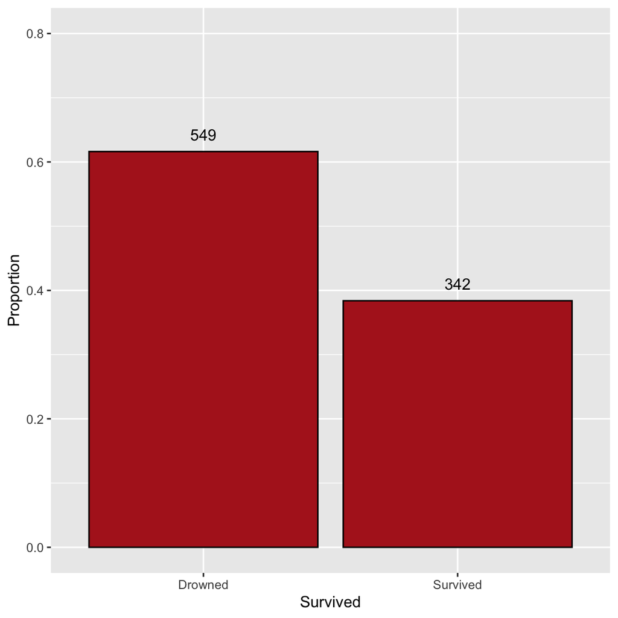

```r
titanic %>%
  ggplot(aes(x=survived_factor, y = ..prop.., group = 1)) +
  geom_bar(fill = 'firebrick', color = 'black') +
  geom_text(stat='count', aes(label=..count..), vjust=-1) +
  xlab("Survived") +
  ylab("Proportion") +
  ylim(0,.8)
```

## Exercise 2: Describe the trend you see above.

ANSWER: More people drowned (versus survived) the titanic.

Now the categorical independent variables.

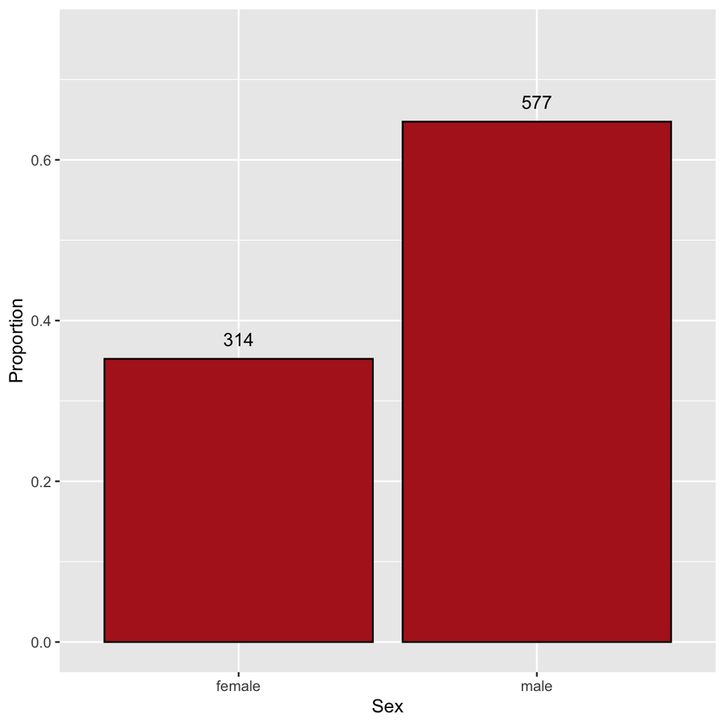

```r
titanic %>%
  ggplot(aes(x=Sex, y = ..prop.., group = 1)) +
  geom_bar(fill = 'firebrick', color = 'black')  +
  geom_text(stat='count', aes(label=..count..), vjust=-1) +
  xlab("Sex") +
  ylab("Proportion") +
  ylim(0,.75)
```

## Exercise 3: Describe the trend you see above.

ANSWER: There were a lot more males on the boat.

## Exercise 4: Produce a bar plot for the Ticket Class variable (Pclass) and describe the trend you see.

Re-create the same plots from the previous examples (colors, axes, proportion, labels) but with the ticket class variable. Interpret what you see.

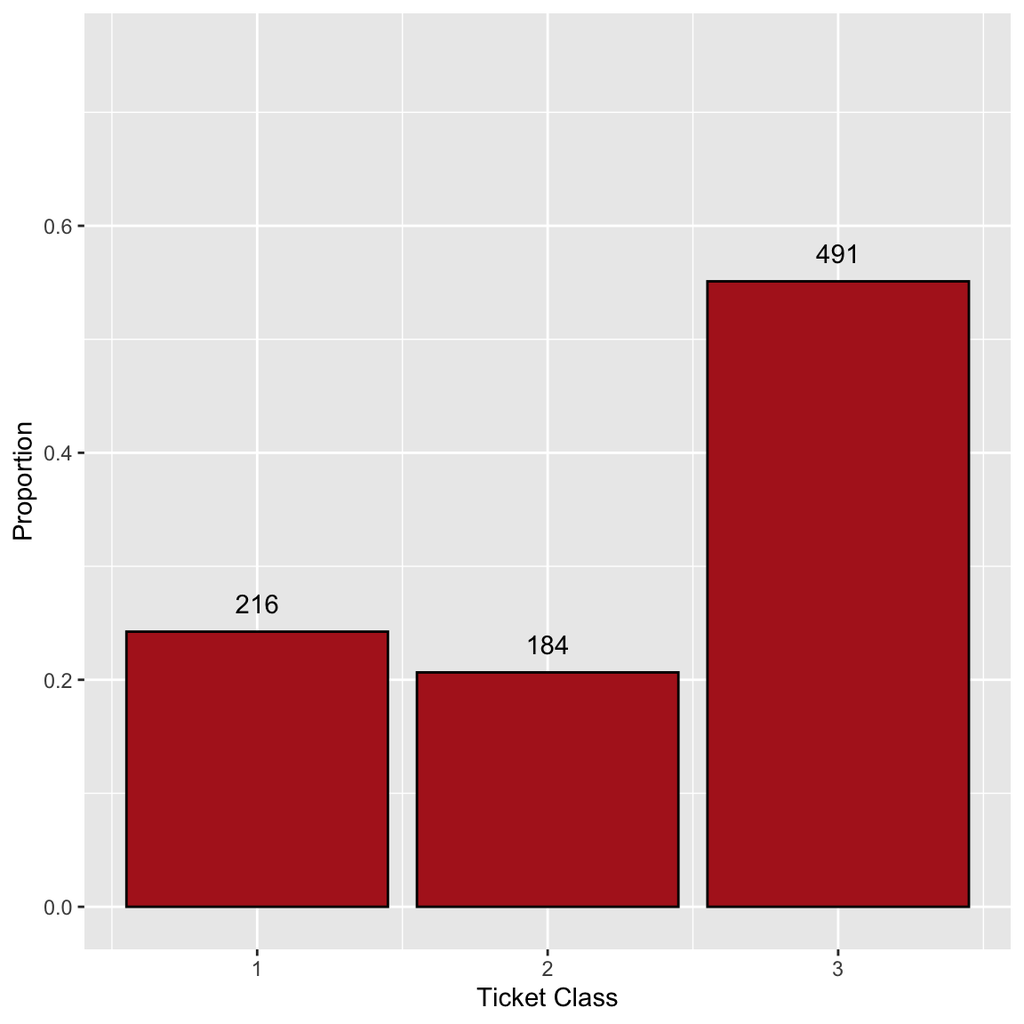

```r
titanic %>%
  ggplot(aes(x=Pclass, y = ..prop.., group = 1)) +
  geom_bar(fill = 'firebrick', color = 'black')  +
  geom_text(stat='count', aes(label=..count..), vjust=-1) +
  xlab("Ticket Class") +
  ylab("Proportion") +
  ylim(0,.75)
```

ANSWER: The majority of passengers were 3rd class.

For continuous variables, histograms allow us to determine the shape of the distribution and look for outliers. The following command produces the histogram.

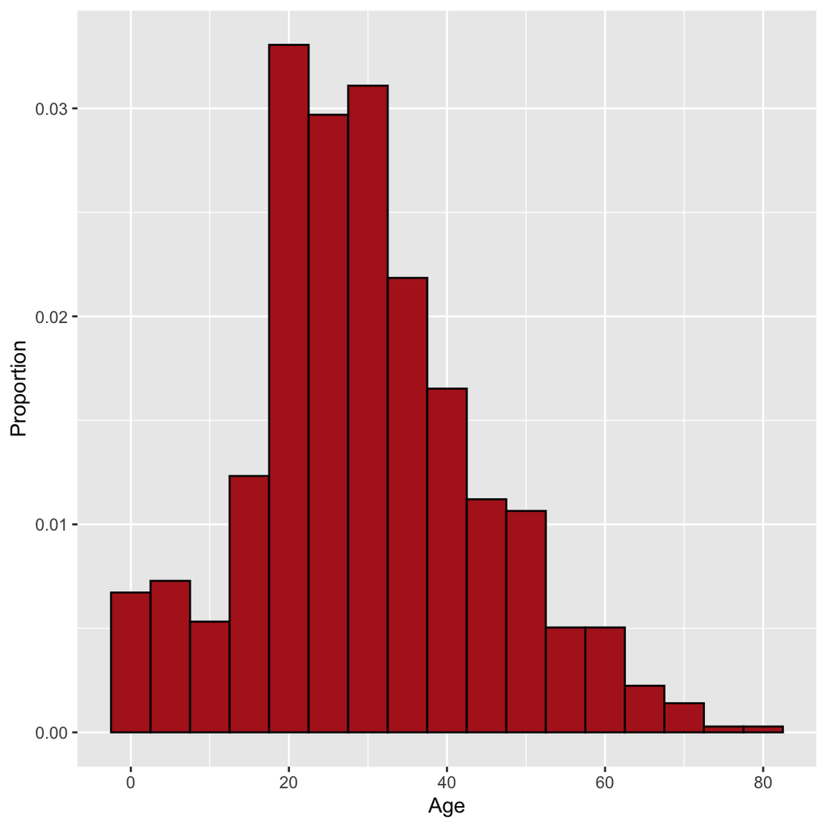

```r
titanic %>%
  ggplot(aes(x=Age, y = ..density.., group = 1)) +
  stat_bin(binwidth = 5,  fill = 'firebrick', color = 'black') +
  xlab("Age") +
  ylab("Proportion")
```

## Exercise 5: Describe the trend you see above.

ANSWER: The passengers center around their 20s, and there are not a lot of passengers over 60.

Prior to moving on to the fully specified model, it is advisable to first examine the simple associations between the outcome and each individual predictor. Doing so can help avoid surprises in the final model. For example, if there is no simple relationship apparent in the data, we shouldn’t be taken aback when that predictor is not significant in the model.

Graphs are again helpful. When the outcome is categorical and the predictor is also categorical, a grouped bar graph is informative. The following is the graph of survival and sex.

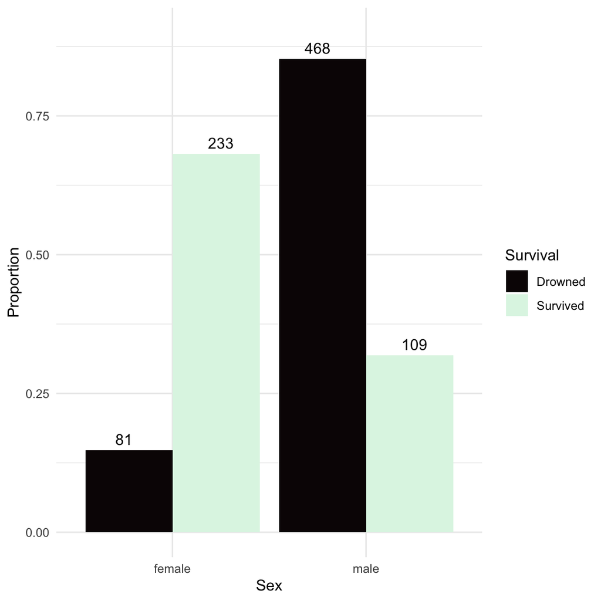

```r
titanic %>%
  ggplot(aes(x=Sex,
             y = ..prop..,
             group = survived_factor,
             fill = survived_factor)) +
  geom_bar( position = 'dodge') +
  geom_text(stat='count',
            aes(label=..count..),
            vjust=-.5,
            position = position_dodge(width = 1))+
  xlab("Sex") +
  ylab("Proportion") +
  ylim(0,.9) +
  labs(fill = "Survival") +
  scale_fill_viridis(option = "mako", discrete = TRUE) +
  theme_minimal()
```

## Exercise 6: Describe the trend you see above.

ANSWER:

## Exercise 7: Produce a bar plot for the Ticket Class variable (Pclass) and describe the trend you see.

Create a similar figure as the previous example for ticket class `Pclass` (i.e., display proportions of survived and drowned within each level of ticket class). Interpret what you see.

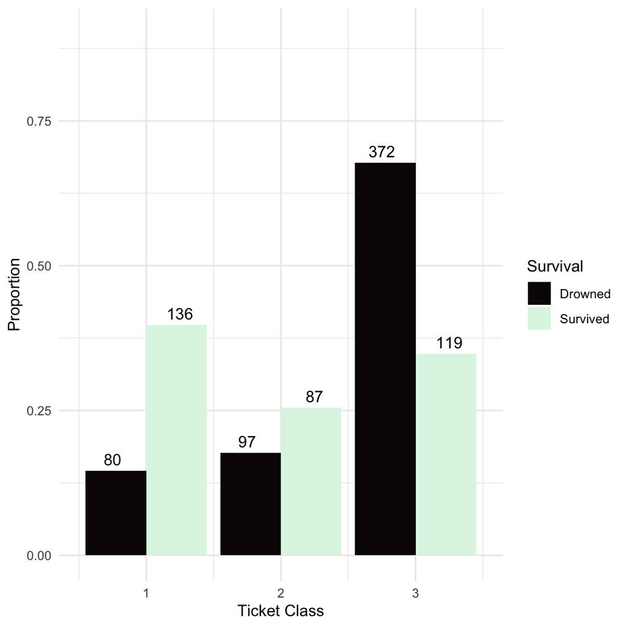

```r
titanic %>%
  ggplot(aes(x=Pclass,
             y = ..prop..,
             group = survived_factor,
             fill = survived_factor)) +
  geom_bar( position = 'dodge') +
  geom_text(stat='count',
            aes(label=..count..),
            vjust=-.5,
            position = position_dodge(width = 1))+
  xlab("Ticket Class") +
  ylab("Proportion") +
  ylim(0,.9) +
  labs(fill = "Survival") +
  scale_fill_viridis(option = "mako", discrete = TRUE) +
  theme_minimal()
```

ANSWER: For class 1, more survived versus drowned. When we get to class 3, this flips and we see more drowned versus survived.

Boxplots are useful for examining the association between a categorical variable and a variable measured on an interval scale.

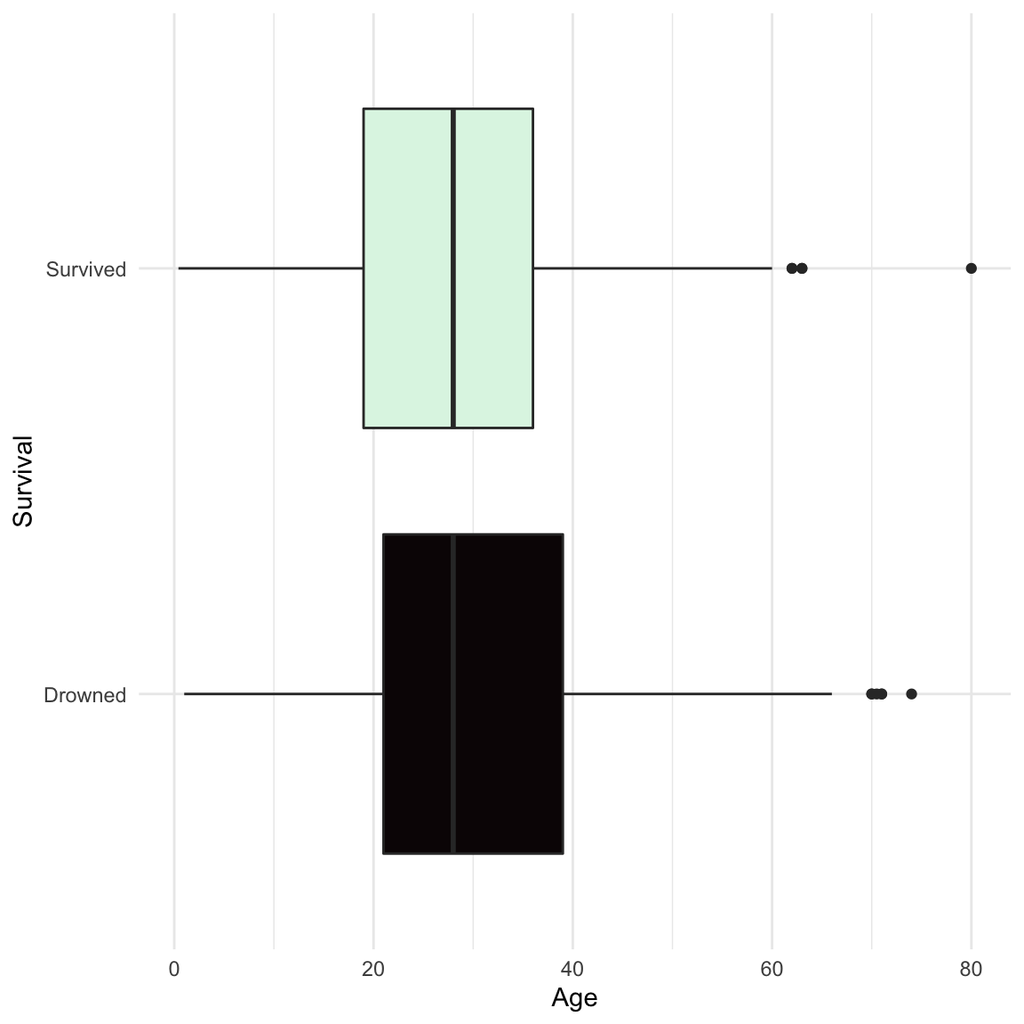

```r
titanic %>%
  ggplot(aes(x = survived_factor,
             y = Age,
             group = survived_factor,
             fill = survived_factor)) +
  geom_boxplot() +
  coord_flip() +
  ylab("Age") +
  xlab("Survival") +
  guides(fill = "none") +
  scale_fill_viridis(option = "mako", discrete = TRUE) +
  theme_minimal()
```

The coord_flip() function is used to keep the dependent variable on the y-axis.

## Exercise 8: Describe the trend you see above.

ANSWER: There doesn’t seem to be a huge distinction in age differences for survival versus drowning. Those who drowned do seem slightly older than those who survived.

Having carefully reviewed the data, we can now move to estimating the model.

**Fitting the Model**

To fit a logistic regression in R, we will use the glm function, which stands for Generalized Linear Model. Within this function, write the dependent variable, followed by ~, and then the independent variables separated by +’s. When the family is specified as binomial, R defaults to fitting a logistic regression model. Note that we are also treating Pclass as a numeric variable here. Note that 0 = drowned and 1 = survived.

```r
#creating the logistic regression model called mod_log
mod_log <-  titanic %>%
  glm(formula = survived_factor ~ Sex + Pclass + Age, family = binomial)

#exponentiation of the model and outputting a table
mod_log %>%
  tidy(exponentiate = T, conf.int = T) %>%
  mutate_if(is.numeric, ~ round(.,3)) %>%
  kable(align = c("l", rep("c", 6)))
```

| term | estimate | std.error | statistic | p.value | conf.low | conf.high |
| --- | --- | --- | --- | --- | --- | --- |
| (Intercept) | 156.962 | 0.502 | 10.069 | 0 | 60.417 | 433.656 |
| Sexmale | 0.080 | 0.207 | -12.168 | 0 | 0.053 | 0.120 |
| Pclass | 0.276 | 0.139 | -9.253 | 0 | 0.208 | 0.360 |
| Age | 0.964 | 0.008 | -4.841 | 0 | 0.949 | 0.978 |

The broom package contains useful functions, like tidy(), for viewing the output from common models. The conf.int = T argument requests confidence intervals.

Because Sex is a factor variable, R will automatically create dummy variables for us. Pclass is an ordered categorical variable, we opt here to treat its effect as linear. The last variable is age. We find that Sex, age, and PClass have significant effects.

We look at our results in terms of odds ratios by setting exponentiate = T in the tidy() function.

This will produce a table where:

- estimate is the odds ratio
- std.error is the standard error of the odds ratio
- statistic is the z-statistic
- p.value is the significance
- conf.low is the lower level of the 95% confidence interval for the odds ratios
- conf.high is the upper level of the 95% confidence interval for the odds ratios

**Interpretation of Odds Ratios**

*An odds ratio less than one means that an increase in x leads to a decrease in the odds that y=1.*

*An odds ratio greater than one means that an increase in x leads to an increase in the odds that y=1.*

## Exercise 9: Interpret the Significant Odds Ratios from the table above.

ANSWER:

Males, compared to females, have a decreased odd of .08 of surviving.

As ticket class increases, passengers have an decreased off of surviving by .28.

As Age increases, passengers have a decreased odd of .96 of surviving.

In general, the percent change in the odds given a one-unit change in the predictor can be determined as:

**% Change in Odds=100(OR-1)**

For example, the odds of surviving are 100(.08-1) = -92% lower for males compared to females.

## Exercise 10: Calculating % change in odds for Pclass

Your job is to use the % change in odds formula to see and interpret whether there is an increase or decrease in odds of surviving (and what the percentage is) for the Pclass Odds Ratio. (Replace the ‘X’ below with the correct term from the model output above)

```r
#  % Change in Odds=100(OR-1)
100 * (.28 - 1)
```

```
## [1] -72
```

ANSWER: The odds of surviving are 100(.28-1) = -72% lower as ticket class increases.

## Exercise 11: Calculating % change in odds for Age

Your job is to use the % change in odds formula to see and interpret whether there is an increase or decrease in odds of surviving (and what the percentage is) for the Age OR. (Replace the ‘X’ below with the correct term from the model output above)

```r
#  % Change in Odds=100(OR-1)

100 * (.96 - 1)
```

```
## [1] -4
```

ANSWER: The odds of surviving are 100(.96-1) = -4% lower as age increases.

# Non-Linear Relationships

For this section you will be using nursing data from TidyTuesday. See https://github.com/rfordatascience/tidytuesday/blob/master/data/2021/2021-08-31/readme.md for more detailed information about the dataset.

```r
set.seed(8765)
nurses <- readr::read_csv('https://raw.githubusercontent.com/rfordatascience/tidytuesday/master/data/2021/2021-10-05/nurses.csv')
nurses$Year <- as.factor(nurses$Year)
nurses$State <- as.factor(nurses$State)

glimpse(nurses)
```

```
## Rows: 1,242
## Columns: 22
## $ State                                             <fct> Alabama, Alaska, Ari…
## $ Year                                              <fct> 2020, 2020, 2020, 20…
## $ `Total Employed RN`                               <dbl> 48850, 6240, 55520, …
## $ `Employed Standard Error (%)`                     <dbl> 2.9, 13.0, 3.7, 4.2,…
## $ `Hourly Wage Avg`                                 <dbl> 28.96, 45.81, 38.64,…
## $ `Hourly Wage Median`                              <dbl> 28.19, 45.23, 37.98,…
## $ `Annual Salary Avg`                               <dbl> 60230, 95270, 80380,…
## $ `Annual Salary Median`                            <dbl> 58630, 94070, 79010,…
## $ `Wage/Salary standard error (%)`                  <dbl> 0.8, 1.4, 0.9, 1.4, …
## $ `Hourly 10th Percentile`                          <dbl> 20.75, 31.50, 27.66,…
## $ `Hourly 25th Percentile`                          <dbl> 23.73, 36.94, 32.58,…
## $ `Hourly 75th Percentile`                          <dbl> 33.15, 53.31, 44.67,…
## $ `Hourly 90th Percentile`                          <dbl> 38.67, 60.70, 50.14,…
## $ `Annual 10th Percentile`                          <dbl> 43150, 65530, 57530,…
## $ `Annual 25th Percentile`                          <dbl> 49360, 76830, 67760,…
## $ `Annual 75th Percentile`                          <dbl> 68960, 110890, 92920…
## $ `Annual 90th Percentile`                          <dbl> 80420, 126260, 10429…
## $ `Location Quotient`                               <dbl> 1.20, 0.98, 0.91, 1.…
## $ `Total Employed (National)_Aggregate`             <dbl> 140019790, 140019790…
## $ `Total Employed (Healthcare, National)_Aggregate` <dbl> 8632190, 8632190, 86…
## $ `Total Employed (Healthcare, State)_Aggregate`    <dbl> 128600, 17730, 17101…
## $ `Yearly Total Employed (State)_Aggregate`         <dbl> 1903210, 296300, 283…
```

## Exercise 12: Assessing Linearity

Residual plots allow us to graphically diagnose issues with linearity.

Your job is to fill in the blanks in the `lm()` argument below. We will be using `Annual Salary Median` as the DV and `Total Employed RN` as the IV.

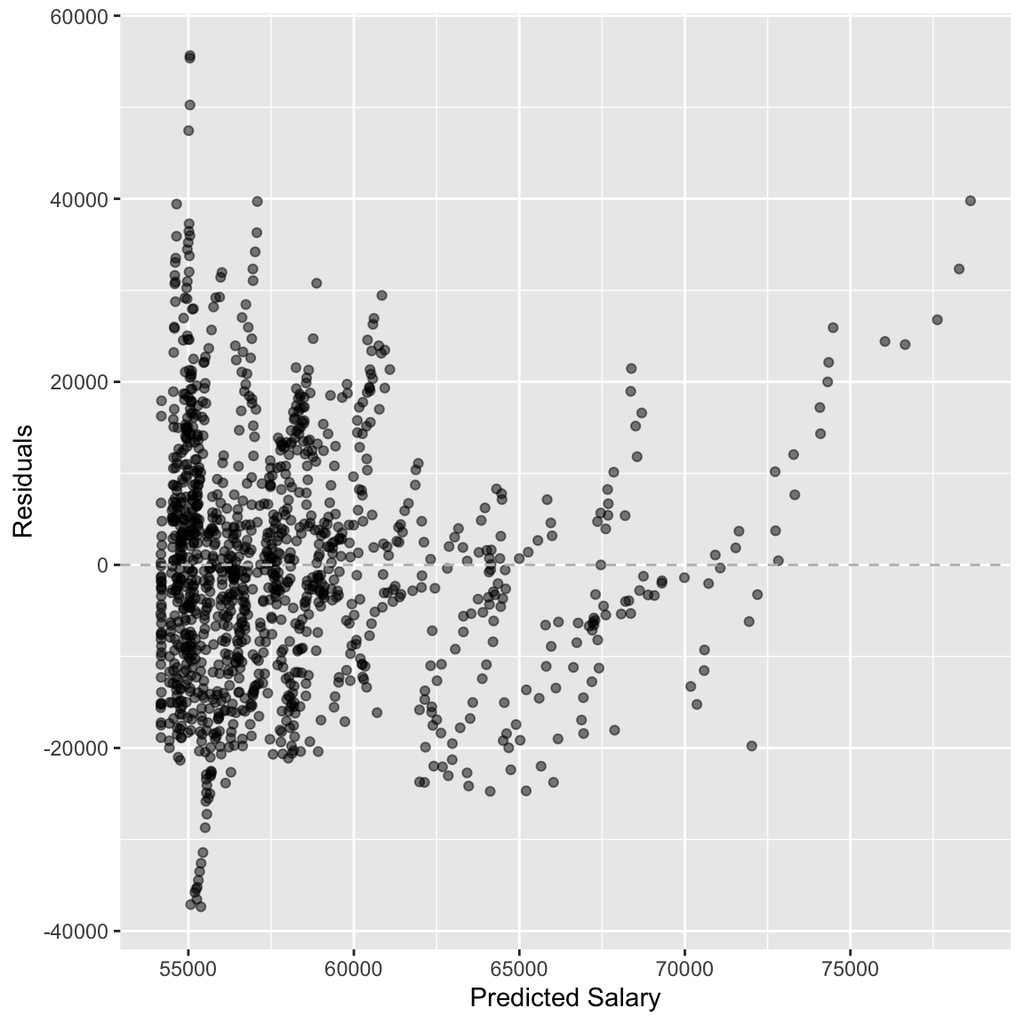

```r
lm(`Annual Salary Median` ~ `Total Employed RN`, data = nurses) %>%
  ggplot(aes(x = .fitted, y = .resid)) +
  geom_point(alpha = 0.5) +
  geom_hline(yintercept = 0, color = "gray", lty = "dashed") +
  labs(x = "Predicted Salary", y = "Residuals")
```

**Interpret what you see above.** Do you see any issues with the above residual plot?

Yes. It is not randomly dispersed around the horizontal 0 line. This tells us we should transform our data.

## Exercise 13: Running the model with log()

Your job is to run an `lm()` with `Annual Salary Median` as the DV and `Total Employed RN` as the IV. Fill in the code below to run the code successfully. Then, interpret the output making sure to interpret it in terms of log annual salary.

For every one unit increase in employed RNs, the log annual salary increases by .0000013

```r
lm(log(`Annual Salary Median`) ~ `Total Employed RN`, data = nurses) %>%
  tidy()
```

```
## # A tibble: 2 × 5
##   term                   estimate   std.error statistic  p.value
##   <chr>                     <dbl>       <dbl>     <dbl>    <dbl>
## 1 (Intercept)         10.9        0.00946       1149.   0
## 2 `Total Employed RN`  0.00000136 0.000000137      9.98 1.27e-22
```

## Exercise 14: Undoing the log()

Interpreting the output in terms of log price is not very helpful, therefore we will exponentiate it.

Replace the X below with the slope estimate for `Total Employed RN`.

```r
exp(.0000013)
```

```
## [1] 1.000001
```

Fill in the blanks in the following interpretation of the slope:

For each additional employed RN there is, the annual median salary is expected to be higher, on average, by a factor of 1.000001.

**Hint**: The first blank should either use the word higher OR lower. The second blank is the result of your exponentiation.